# 이름은 그대로, 모델은 바뀌었다

’더 짧고 빨라졌다’는 같은 이름 아래의 교체를 내 과제 65쌍으로 대조하다 — 계측학(소급성·반복성) × 물가지수 경제학(슈링크플레이션·품질조정) × 화용론(그라이스의 양의 격률)

저자

Insight Lab × Claude

공개

2026년 10월 24일

**노트핵심 문장**

# 1 같은 이름 아래에서 일어난 일

2026년 10월 17일, DeepSeek는 API 변경 기록에 짧은 공지를 올렸다. **V4.1 Flash를 `DeepSeek-V4.1-Flash-1017`로 올렸다. 호출 방식과 가격은 그대로다. `deepseek-flash`라는 이름을 계속 쓰면 최신 모델로 연결된다.** 그리고 한 줄이 더 있었다. **작업 시간과 출력 길이를 줄였다.**

얼마나 줄였는지는 없었다. 벤치마크 점수는 여러 개가 숫자로 적혀 있었지만, 길이와 시간에 대해서는 숫자가 하나도 없었다.

이 공지가 처음은 아니다. 5주 전인 9월 10일, V4.1 Flash가 처음 나올 때도 같은 일이 있었다. 옛 이름 `deepseek-v4-flash`는 은퇴했고, **그 이름으로 들어오는 호출은 새 모델로 임시 연결된다**고 적혀 있었다. 5주 사이에 같은 계열의 이름이 두 번 다른 모델을 가리키게 됐다.

같은 주 10월 21일에는 Anthropic이 Claude Duet을 공개했다. 메일과 일정을 지켜보다 먼저 일을 처리하는 배경 에이전트다. 에이전트는 모델을 이름으로 부른다. 그 이름 뒤가 바뀌면, 에이전트는 어제와 같은 코드로 다른 판단을 한다.

그래서 물었다. **“짧아졌다”는 주장은 내 과제에서 재현되는가.** 그리고 그보다 먼저, **재현되는지 아닌지를 내가 알아낼 수 있기는 한가.**

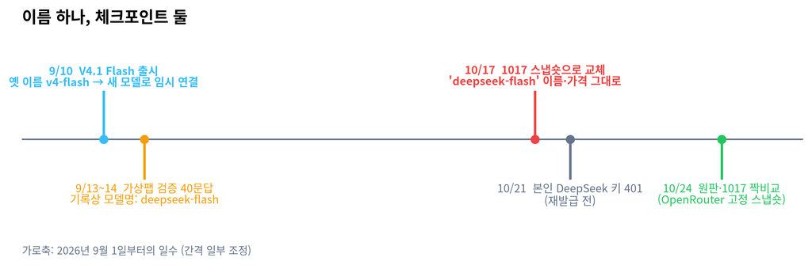

그림 1: 같은 이름이 가리키는 대상의 변화. 점선 위 사건은 제공사 공지, 아래는 이 글의 기록. 9월 13~14일의 가상팹 검증은 ’deepseek-flash’라는 이름으로 기록됐지만, 그 이름은 지금 다른 체크포인트를 가리킨다. 출처: DeepSeek API 변경 기록(2026-09-10, 2026-10-17), OpenRouter 모델 등록일, 본인 실행 기록.

# 2 실측 설계

DeepSeek 본사 API는 이제 1017만 내준다. 원판은 본사에서 사라졌다. 그러나 가중치가 공개돼 있어서, 여러 호스팅 업체가 **두 스냅숏을 각각 다른 이름으로 고정해** 서비스한다. OpenRouter에는 `deepseek-v4.1-flash`(9월 10일 등록)와 `deepseek-v4.1-flash-1017`(10월 17일 등록)이 나란히 있다.

이것이 비교를 가능하게 했다. 조건은 셋이다.

1. **같은 서버.** 두 스냅숏 모두 같은 제공사(Nebius), 같은 양자화(fp8)로만 받았다. 다른 제공사로 넘어가는 것은 막았다. 제공사가 다르면 속도도, 출력도 달라질 수 있다.
2. **같은 질문.** 합성 예문은 쓰지 않았다(SP25의 교훈). 과제는 두 종류다.
   - **과제 A — 분석 문답 40건.** 9월 13~14일 가상팹 검증에서 실제로 던진 질문 40개와, 그때 쓰인 공정 CSV(학습용 가상 데이터) 원문을 그대로 붙였다. 답의 길이가 정해져 있지 않은 과제다.
   - **과제 B — 번역 25조각.** 연구 원고를 영어에서 한국어로 옮기는 실제 번역 작업이다. 숫자·수식·인용키를 바꾸지 말고, 더하지도 빼지도 말라는 규칙이 붙어 있다. 답의 길이가 **원문에 묶인** 과제다.
3. **기본 설정.** 사용자가 이름만 바꿔 부를 때처럼 추론 설정을 건드리지 않았다. 최대 출력은 8,000토큰.

각 과제를 두 스냅숏에 같은 시각대에 보냈다. 원래 계획은 전부 두 번씩이었다. 그러나 이 실험에 쓴 키에는 사용자가 걸어둔 **1달러 상한**이 있었고, 0.95달러를 쓴 시점에서 막혔다. 상한은 올리지 않았다. 그래서 **짝비교 65쌍(A 40, B 25)** 은 완결됐고, **반복 측정은 A의 10문항**에만 남았다. 반복 10문항이 이 글의 잡음 바닥이다.

# 3 주장 1: “짧아졌다” — 재현되지 않았다

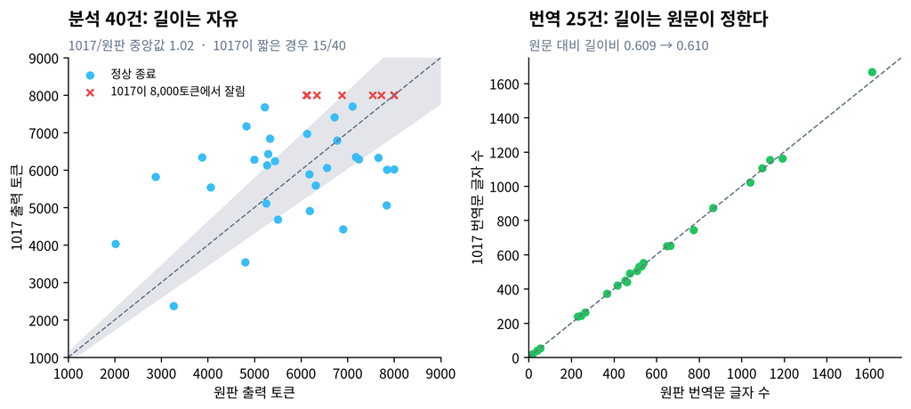

그림 2: 같은 질문에 대한 두 스냅숏의 출력량. 점 하나가 질문 하나다. 대각선 위에 있으면 1017이 더 길다. 왼쪽(분석)은 추론 포함 전체 출력 토큰, 오른쪽(번역)은 화면에 보이는 번역문 글자 수. 회색 띠는 같은 스냅숏을 두 번 돌렸을 때의 출렁임(중앙값 ±16%). 출처: 본 실험 짝비교 65쌍.

**분석 과제에서 1017은 원판보다 짧지 않았다.** 전체 출력 토큰의 비율(1017÷원판) 중앙값은 **1.02**, 붓스트랩 95% 구간은 **0.96~1.16**이다. 40문항 중 1017이 짧았던 것은 15건뿐이다. 추론 토큰만 보면 오히려 **1.09배**였다(구간 0.93~1.18 — 늘었다고도 말할 수 없다).

**번역 과제에서는 아무것도 달라지지 않았다.** 원문 대비 번역문 길이비는 **0.609 대 0.610**. 같은 조각끼리의 차이는 중앙값 0.7%다. 원문 숫자 309개 중 빠진 것은 **둘 다 0개**, 수식 7개도 둘 다 그대로였다. 차이는 단 하나 — 1017이 25조각 중 1조각에서 제목 표시 `##` 뒤의 빈칸을 빼먹어, 그 제목이 문서에서 제목으로 인식되지 않게 됐다.

(처음 집계에서는 숫자 누락이 115 대 118건으로 나왔다. “114건”처럼 한글이 붙은 숫자를 추출 규칙이 숫자로 보지 못한 내 오류였다. 규칙을 고쳐 다시 셌다.)

# 4 주장 2: “빨라졌다” — 재현됐다, 그러나 다른 이유로

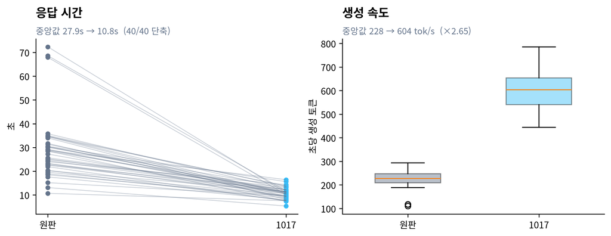

그림 3: 응답 시간과 초당 생성 토큰. 같은 제공사·같은 양자화에서 받은 값이다. 1017은 40쌍 전부에서 더 빨랐지만, 출력량은 같았다. 빨라진 것은 길이가 아니라 토큰을 뽑는 속도다. 출처: 본 실험 분석 과제 40쌍.

시간은 확실히 줄었다. 분석 과제의 응답 시간 비율 중앙값은 **0.41**(95% 구간 0.36~0.46), **40쌍 전부**에서 1017이 빨랐다. 번역에서도 0.51이었다.

그러나 출력량이 같았으므로, 이 단축은 “짧게 답해서”가 아니다. 초당 생성 토큰이 **228에서 604로 2.65배** 올랐다. 같은 문장을 더 빨리 뽑았을 뿐이다.

그런데 생성 속도는 모델 가중치만의 성질이 아니다. 같은 제공사라도 어떤 GPU에, 몇 개의 요청을 묶어, 어떤 가속 기법으로 올렸는지가 속도를 정한다. 1017 쪽 서버가 더 좋은 자리를 받았을 수 있다. 이 실험으로는 둘을 가를 수 없다. 확실한 것은 하나다. **사용자가 확인할 수 있었던 유일한 개선은, 모델이 아니라 서버에서 온 것일 수 있는 개선이었다.**

# 5 경계에서 나온 것: 짧아질 수 있는 곳은 잴 수 없는 곳이다

여기서 두 가지 측정이 겹친다.

첫째, **청구되는 토큰의 대부분은 보이지 않는다.**

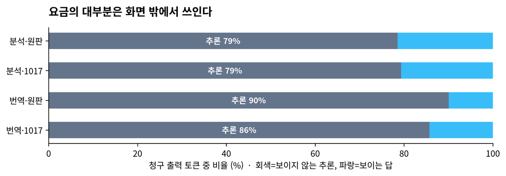

그림 4: 청구된 출력 토큰의 구성. 추론 토큰은 요금에 포함되지만 사용자 화면에는 나오지 않는다. 출처: 본 실험 짝비교 65쌍의 중앙값.

분석에서는 **79%**, 번역에서는 **86~90%** 가 추론 토큰이었다. 번역문 300토큰을 받으려고 2,000토큰 넘게 값을 치른다.

둘째, **보이지 않는 부분은 한 번 부를 때마다 크게 출렁인다.**

같은 질문을 같은 스냅숏에 두 번 보냈을 때(10문항), 전체 출력 토큰은 중앙값으로 **16~18%** 달라졌다. 추론 토큰만 보면 22~29%였다. 번역에서는 화면에 보이는 번역문 길이가 거의 고정(짝 간 로그 표준편차 0.04)이었지만, 그 번역을 만들려고 쓴 추론량은 조각마다 몇 배씩 달랐다(로그 표준편차 1.29).

이 두 사실을 겹치면 하나의 결론이 나온다.

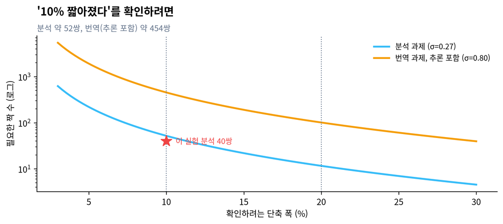

그림 5: 줄어든 정도를 확인하는 데 필요한 짝 수(검정력 80%, 유의수준 5%). 짝 간 차이의 로그 표준편차를 이 실험에서 그대로 썼다(분석 0.27, 번역 0.80). 별표는 이 실험의 표본 수. 출처: 본 실험 짝비교로 추정.

10% 단축을 확인하려면 분석 과제로 **약 52쌍**, 번역 과제로는 **약 450쌍**이 필요하다. 혼자 쓰는 사람이 이름이 바뀔 때마다 이만큼을 돌리지는 않는다.

그리고 줄일 수 있는 자리 자체가 정해져 있다. 번역처럼 **보이는 길이가 원문에 묶인 과제에서는 줄일 곳이 추론뿐**이다. 분석처럼 **보이는 길이가 자유로운 과제에서는, 그 자유 때문에 한 번 한 번이 출렁인다.** 어느 쪽이든 “짧아졌다”는 주장이 작동할 수 있는 자리는 **사용자가 혼자서는 확인할 수 없는 자리**다.

# 6 세 분야가 각각 말하는 것

**계측학 — 소급성과 반복성.** 국제계측용어집(VIM 2.41)은 측정 결과의 소급성을 “문서화된, 끊기지 않은 교정의 사슬을 통해 기준에 연결될 수 있는 결과의 성질”로 정의한다. 소급성은 장비의 성질이 아니라 **결과의 성질**이다. 9월 13일에 “deepseek-flash로 가상팹 6개 시나리오를 검증했다”고 적은 내 보고서는, 그 이름이 다른 체크포인트를 가리키게 된 10월 17일에 기준과의 연결이 끊겼다. 계측학은 또 하나를 요구한다. 변화를 말하려면 **장비의 반복성이 그 변화보다 작아야 한다.** 이 실험에서 한 번 호출의 반복성은 ±16% 안팎이었다. 10% 변화는 이 장비로 한 번에 잴 수 없다.

**물가지수 경제학 — 슈링크플레이션과 품질조정.** 미국 노동통계국(BLS)은 소비자물가지수를 만들 때 포장 크기가 줄면 **단위당 가격이 오른 것으로** 처리하고, 크기 변화를 빼고 계산한 연구용 지수(R-CPI-SC)를 따로 낸다. 이 조정이 가능한 이유는 하나다. **용량이 포장에 인쇄돼 있다.** 언어모델의 가격은 토큰당으로 매겨지지만, 사는 사람이 원하는 것은 토큰이 아니라 **끝난 과제 하나**다. 과제당 토큰은 고정된 값이 아니라 퍼져 있는 확률변수이고, 그 79~90%는 화면에 나오지 않는다. “토큰당 가격은 그대로, 출력은 짧아졌다”는 공지는 **용량이 인쇄되지 않은 포장의 용량 변경 공지**다. 이번에는 줄지 않았으니 슈링크플레이션도 아니다. 다만 줄었든 늘었든, 그 방향을 사는 쪽이 셈할 수 없다는 점이 같다.

**화용론 — 그라이스의 양의 격률.** 그라이스는 대화의 협력 원리 중 하나로 **“필요한 만큼 정보를 주되, 필요 이상은 주지 말라”** 를 들었다. 무엇이 “필요한 만큼”인지는 말하는 쪽이 아니라 **과제가** 정한다. 번역에서는 원문이 양을 정한다 — 그래서 두 스냅숏의 번역문 길이가 0.7% 안에서 일치했다. 분석에서는 질문이 양을 느슨하게 정할 뿐이다 — 그래서 같은 스냅숏도 한 번 한 번 다르게 말했다. 길이가 같아도 그 안에 무엇을 넣는지는 달라질 수 있어서 근거 숫자의 개수도 셌다. 1017 쪽이 0.89배로 적은 경향은 있었지만 95% 구간(0.85~1.02)이 1을 넘었고, 1,000자당 밀도로는 36쌍 중 20쌍에서만 줄었다. **우연과 구별되지 않는다.** 양의 격률이 묶지 않는 곳에서는 길이도, 길이 안의 내용도 이 표본 크기로는 잡히지 않는다.

# 7 경계에서만 나오는 명제

세 분야를 따로 놓으면 각각 상식이다. 측정에는 기준과 반복성이 필요하고, 가격은 단위가 보여야 비교되고, 말의 적정량은 맥락이 정한다.

겹치면 이런 명제가 나온다.

> **떠다니는 이름 아래에서 제공사의 “더 짧다”는 주장은, 양의 격률이 길이를 묶지 않는 곳(자유 서술)과 사용자가 볼 수 없는 곳(추론)에만 작용할 수 있다. 그런데 그 두 곳은 정확히 반복성이 가장 나쁜 곳이다. 그러므로 이 주장은 개인 사용자에게 구조적으로 검증 불가능하고, 검증 가능한 개선(속도)은 모델이 아니라 서버의 성질로 나타난다.**

계측학만으로는 “반복성이 나쁘다”까지다. 경제학만으로는 “단위가 안 보인다”까지다. 화용론만으로는 “과제마다 적정 길이가 다르다”까지다. **“주장이 작동하는 자리와 잴 수 없는 자리가 같은 자리다”** 는 셋을 겹쳐야 보인다.

# 8 설계로 옮기면

1. **이름 대신 스냅숏을 부른다.** `deepseek-flash`가 아니라 `deepseek-v4.1-flash-1017`처럼 날짜가 박힌 이름을 쓴다. 본사가 스냅숏 이름을 주지 않으면, 고정 이름을 주는 중계 서비스를 쓴다.
2. **내 교정 세트를 만든다.** 내 실제 과제 50건 이상을 따로 보관한다. 이름 뒤가 바뀌었다는 공지가 오면 그 세트를 옛 스냅숏과 새 스냅숏에 같이 돌린다. 길이만 보지 말고 **과제의 핵심 산출물**(근거 숫자, 형식 규칙 위반 — 이번의 `##` 빈칸 같은 것)을 센다.
3. **반복성을 먼저 잰다.** 같은 스냅숏을 두 번 돌린 차이가 비교의 바닥이다. 바닥보다 작은 차이는 보고하지 않는다.
4. **과제당 비용으로 셈한다.** 토큰당 가격이 아니라 내 교정 세트 1회 실행의 총비용을 기록한다. 그 숫자가 내 물가지수다.
5. **출력 예산을 추론까지 계산해 잡는다.** 이번 1017은 8,000토큰 예산을 추론에 다 쓰고 본문 0자로 돌아온 경우가 있었다. 기록에 “성공”으로 남는 빈 답은 SP38에서 본 그대로의 위험이다.

# 9 내 9월 보고서는 지금 무엇을 가리키는가

이 실험의 출발점은 내 기록이었다. 9월 13~14일, 가상팹 앱의 AI 연결을 검증하며 deepseek-flash에 40개 질문을 보냈고, 답 길이 1,104~1,442자, 응답 5~14초가 로그에 남았다. 그 보고서는 “이 경로로 학생들이 쓸 수 있다”고 결론냈다.

오늘 그 결론을 다시 확인하려 했을 때 세 가지가 막혀 있었다. 본사 API의 같은 이름은 다른 모델을 가리키고, 내 키는 10월 21일부터 무효였고, 앱이 그때 붙였던 시스템 문구는 그 뒤 배포에서 바뀌었을 수 있다. **9월의 숫자는 지금 어떤 기준에도 연결되지 않는다.** 재현할 수 있었던 것은 중계 서비스가 옛 스냅숏을 고정 이름으로 남겨둔 덕분이었다. 내가 지킨 것이 아니라 남이 남겨둔 것이다.

**경고반대 해석과 한계**

**1. 제공사의 주장은 다른 조건에서 참일 수 있다.** DeepSeek가 말한 “작업 시간과 출력 길이”는 본사 서버, 본사 기본 설정, 그리고 여러 단계를 도는 에이전트 과제에서 잰 것일 수 있다. 이 실험은 단발 질문, 제3자 서버(Nebius)다. 에이전트 과제에서 단계 수가 줄었다면 그것은 여기서 보이지 않는다. **“재현되지 않았다”는 “거짓이다”가 아니다.**

**2. 서버가 같아도 포장이 다를 수 있다.** 같은 제공사에서도 두 스냅숏의 프롬프트 토큰 수가 질문마다 정확히 63개씩 달랐다. 대화 템플릿이나 기본 시스템 문구가 다르다는 뜻이다. 속도 차이도 모델보다 배치 자리·하드웨어 차이일 수 있다. 이 실험은 “모델 대 모델”이 아니라 **“이 제공사가 내주는 두 이름 대 두 이름”** 을 비교한 것이다.

**3. 표본이 작고, 반복은 더 작다.** 짝비교는 65쌍이지만 반복 측정은 분석 10문항뿐이다. 키에 걸린 1달러 상한에서 멈췄다. 잡음 바닥(±16~18%)의 추정 자체가 10개 위에 서 있다.

**4. 질문이 잘려 있었다.** 9월 기록은 질문을 300자에서 잘라 저장했다. 출력 형식을 지정한 끝부분이 빠진 질문이 있다. 두 스냅숏에 같은 질문을 보냈으므로 비교는 공정하지만, 9월의 실제 상황과 같은 질문은 아니다.

**5. 답의 질은 재지 않았다.** 길이·속도·형식 충실도만 쟀다. 근거 숫자 개수와, 그 숫자가 CSV에 실제로 있는 비율(0.84 대 0.82)은 거친 대리지표이고 둘 다 차이가 없었다. 분석 답의 질을 판정하려면 사람의 채점이나 정답이 있는 과제가 필요하다. 또 이 글의 첫 집계에는 한글이 붙은 숫자를 놓치는 추출 오류가 있었고, 발견 후 전부 다시 셌다.

**6. 반대 방향의 해석.** 짧아지지 않은 것이 오히려 다행일 수 있다. 번역처럼 충실도가 중요한 과제에서 “짧아졌다”는 것은 누락을 뜻한다. 1017이 번역 길이를 그대로 지킨 것은, 단축이 **과제를 가려서** 일어났거나(필요한 곳에서는 줄이지 않음) 단발 질문에는 아예 적용되지 않았다는 증거로도 읽을 수 있다. 이 해석이 맞다면 문제는 모델이 아니라 **조건 없이 한 줄로 쓰인 공지**다.

# 10 남는 질문

에이전트는 점점 모델을 이름으로 부르고, 배경에서, 사람 없이 돈다. Duet이 그렇고, 이 글을 예약 실행한 내 비서도 그렇다. 이름 뒤가 바뀌는 날 에이전트는 공지를 읽지 않는다.

그때 남는 질문은 새 모델이 더 좋은가가 아니다.

**바뀐 줄 아는 데 몇 건이 필요한가.** 이 글의 측정으로는 10% 차이에 약 52건이었다. 그 숫자를 줄이는 것 — 반복성을 높이고, 단위를 인쇄하게 하는 것 — 이 제공사가 할 수 있는 가장 정직한 개선이다.

# 11 참고 문헌

- DeepSeek, API Docs “Change Log”, 2026-09-10(V4.1 Flash 출시, 옛 이름 임시 연결) 및 2026-10-17(V4.1-Flash-1017, 호출 방식·가격 동일, 작업 시간·출력 길이 단축 언급). https://api-docs.deepseek.com/updates/
- OpenRouter 모델 목록 및 제공사별 엔드포인트, `deepseek/deepseek-v4.1-flash`(2026-09-10 등록)·`deepseek/deepseek-v4.1-flash-1017`(2026-10-17 등록), 2026-10-24 조회.
- Anthropic, Claude Duet 연구 프리뷰 공개(2026-10-21) — 언론 보도로 확인(예: iPhone in Canada, 2026-10-21).
- JCGM 200:2012, *International vocabulary of metrology (VIM)*, 3rd ed., 2.41 metrological traceability; NIST, “Metrological Traceability” 정책 페이지.
- U.S. Bureau of Labor Statistics, “Measuring shrinkflation and its impact on inflation,” *Beyond the Numbers* vol. 12; BLS Research series R-CPI-SC; U.S. GAO, GAO-25-107451 (2025).
- Grice, H. P. “Logic and Conversation.” In Cole & Morgan (eds.), *Syntax and Semantics 3: Speech Acts*, Academic Press, 1975.
- Insight Lab SP25 「싸진 판단은 어디서 정직한가」(합성 예문 금지 원칙), SP38 「로그가 잘라낸 마지막 문장」(성공으로 기록되는 빈 출력).
- 본 실험 원자료: `output/data/sp43_flash_ab.json` — 호출 260회(성공 151, 예산 상한 차단 109) 각각의 과제 구분·스냅숏·반복 번호·토큰·시간·비용·종료 사유·글자 수·숫자 개수·충실도 점검 결과. 질문·답변·번역 텍스트는 포함하지 않았다.